# Co-Medication rate of Insulin and Byetta

Technical assessment for **Prospection

[Dr. Sergio Ruiz Carmona](https://www.ruizsergio.com/) - 7 June 2022

# Aim

To calculate the **‘co-medication rate’** of two drugs, **Insulin** (In) and **Byetta** (By).

- Co-medication means patient taking both drugs at the same time.

# Data

We are given a list of **patient ID’s**, **dates**, and **drug purchases.**

See diagram below:

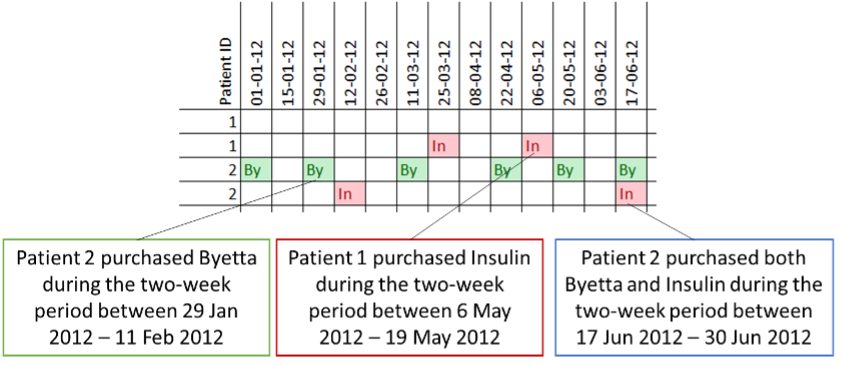

However, we have a couple assumptions to consider:

- Each date represents the two-week period in which the purchase took place. *We do not know the exact date of purchase.*
- Insulin lasts for approximately 90 days for each purchase.
- Byetta lasts for approximately 30 days for each purchase.

# Tasks

## 1.- Co-medication rate

**Design an algorithm to calculate co-medication rate (assume all records must be used in this algorithm)**

1. What is your definition of co-medication rate?
2. How do you calculate this co-medication rate based on your definition? Please provide one of the following:
   - Code design flow chart or diagram
   - Pseudo code
   - **Actual code in R**, python, or SAS
   - Excel file

To calculate it, we first need to know when a patient is actually taking the medication.  
Since the data we are provided only tells us the 2-week periods when a patient **bought** each of the medicines, we will consider the following assumptions:

- The patient buys the medication on the first day of the specified fortnight
- The patient takes the medication for all its lifespan: 90 days (6 fortnights) for Insulin and 30 days (2 fortnights) for Byetta
- All patients have 100% adherence

See the Improvements section below for comments regarding these assumptions.

**b.**  
Please, see the subsections below with the actual code in R and stepwise comments to:

- Set up the R session (load libraries and define functions)
- Read and clean the Excel file with the data
- Process all the records to create a *tidy* data set to facilitate results visualization

### Code: Load libraries

First, I load the required libraries for the data processing and visualization steps.

I will use the `tidyverse` package collection for most of the data processing, `readxl` to read the input Microsoft Excel spreadsheet, `docstring` to create function documentation and `ggtext`, `DT` and `cowplot` for improving the results visualization.

```r
library(tidyverse)
library(readxl)
library(docstring)
library(ggtext)
library(DT)
library(cowplot)
```

### Code: Create functions

Next, I define a couple of functions that are useful for processing the input and for possible future re-uses.

```r
convert_to_date <- function(date_int, origin_date = "1899-12-30"){
  #' Convert integer to date format
  #'
  #' Importing from tables and other files, such as xlsx,
  #' can convert dates into numbers, raising problems for the analysis.
  #' This function converts a number into a correctly formatted date string, based on an origin date.
  #'
  #' @param date_int Numeric integer that is actually a date
  #' @param origin_date Origin date to use (e.g. for Microsoft Excel, it is 30th of Dec 1899)
  #'
  #' @return Returns a date-formatted string with the corresponding date
  as.Date(as.numeric(date_int), origin = origin_date)
}

get_lag_fun <- function (lag_rows) {
  #' Create function to check lag rows
  #'
  #' Create the function for dplyr to check whether a medicine was bought previously
  #' You can choose how many rows (== "fortnights") to check back.
  #' As an example, since insulin lasts for 90 days, we should check the previous 6 fortnights:
  #' If the patient bought insulin on the previous 6 rows, then we assume they are taking it
  #'
  #' @param lag_rows Number of rows (fortnights) in the past to check
  #'
  #' @return Returns an ifelse function call in the correct format for dplyr
  paste0("~ ifelse(.x == 0 & (",
         paste(paste0("dplyr::lag(.x, n = ",seq(lag_rows), ", default = 0)"),
               collapse = " == 1 | "), "), 1, .x)")
}
```

### Code: Read and process data

Now, I read the input file and process it to calculate the co-medication rate.

Just after being laoded, the column names are transformed to the correct date and format.  
See the table below for a small sample of the input:

```r
# read input from the provided excel file
patients <- read_xlsx("2._byetta_insulin_music_diagram_v5 (30) (12).xlsx")
# convert column names to the correct dates
names(patients) <- c("id", as.character(convert_to_date(names(patients)[-1])))
patients %>%
  select(1:8) %>%
  head(n=4)
```

| id | 2012-01-01 | 2012-01-15 | 2012-01-29 | 2012-02-12 | 2012-02-26 | 2012-03-11 | 2012-03-25 |
| --- | --- | --- | --- | --- | --- | --- | --- |
| 1 | NA | NA | NA | NA | NA | NA | NA |
| 1 | NA | NA | NA | NA | NA | NA | In |
| 2 | By | NA | By | NA | NA | By | NA |
| 2 | NA | NA | NA | In | NA | NA | NA |

Next, the input is processed and transformed to calculate when each patient was taking each of the medications and their corresponding co-medication rate.  
**Please, read the inline comments below to see what each of the steps is doing:**

```r
comed <- patients %>%
  # pivot data set to get one row per patient, medicine and date
  pivot_longer(-id, names_to = "date", values_to = "med") %>%
  # transform date from character to date format
  mutate(date = as.Date(date)) %>%
  # grouping by patient and date allows us to check which medicines were bought at each period
  group_by(id, date) %>%
  arrange(id, date) %>%
  # create binary variables for buying each of the medicines
  mutate(bought_ins = ifelse("In" %in% med, 1, 0),
         bought_by = ifelse("By" %in% med, 1, 0)) %>%
  # get only the first row of each group and remove the medicine column, already processed
  filter(row_number() == 1) %>%
  select(-med) %>%
  ungroup() %>%
  group_by(id) %>%
  # following the assumptions above, we create a binary variable for each medicine that
  #   corresponds to actually taking them
  # for Insulin, we check if it was bought on any of the previous 6 fortnights
  # for Byetta, we check the previous 2 fortnights
  mutate(across(bought_ins, eval(str2lang(get_lag_fun(6))), .names = "used_ins")) %>%
  mutate(across(bought_by, eval(str2lang(get_lag_fun(2))), .names = "used_by")) %>%
  # finally, we create a variable for the number of medicines used during each period
  # and get the co-medication rate by diving the periods with 2 medicines by the periods being medicated
  mutate(n_med = used_ins + used_by,
         comed_rate = round(sum(ifelse(n_med == 2, 1, 0)) / sum(ifelse(n_med != 0, 1, 0)) * 100,1),
         name = paste0("#",id, " (", comed_rate, "%)")) %>%
  ungroup()
```

As an example, this is how the data set looks like after finishing all the processing (5 random records):

| id | date | bought_ins | bought_by | used_ins | used_by | n_med | comed_rate | name |
| --- | --- | --- | --- | --- | --- | --- | --- | --- |
| 22 | 2012-01-01 | 0 | 0 | 0 | 0 | 0 | 0.0 | #22 (0%) |
| 23 | 2012-07-29 | 0 | 0 | 1 | 0 | 1 | 0.0 | #23 (0%) |
| 45 | 2012-04-08 | 0 | 0 | 1 | 0 | 1 | 34.7 | #45 (34.7%) |
| 53 | 2014-01-12 | 0 | 0 | 0 | 0 | 0 | 18.9 | #53 (18.9%) |
| 79 | 2013-06-02 | 0 | 1 | 1 | 1 | 2 | 85.7 | #79 (85.7%) |

## 2.- Results visualization

**How would you visualize the results of your measurement?**

- What charts or graphs would be useful?

There are different possibilities, depending on the question we want to answer besides knowing their co-medication rate.

To begin with, a simple plot or table showing the number of fortnights with each of the medications and when they were co-medicating, together with the calculated co-medication rate for each of the patients would be a quick way to see the results we want:

- Interactive table:

| Patient ID | Fortnights with only Insulin | Fortnights with only Byetta | Fortnights with Insulin and Byetta | Co-medication rate (%) |
| --- | --- | --- | --- | --- |
| 40 | 1 | 0 | 51 | 98.1 |
| 41 | 2 | 0 | 52 | 96.3 |
| 24 | 5 | 0 | 50 | 90.9 |
| 5 | 6 | 0 | 48 | 88.9 |
| 51 | 1 | 6 | 48 | 87.3 |
| 50 | 5 | 1 | 36 | 85.7 |
| 79 | 7 | 0 | 42 | 85.7 |
| 76 | 5 | 9 | 37 | 72.5 |
| 43 | 13 | 8 | 32 | 60.4 |
| 15 | 8 | 10 | 27 | 60 |

[output cut: 58 more lines]

- Plot:

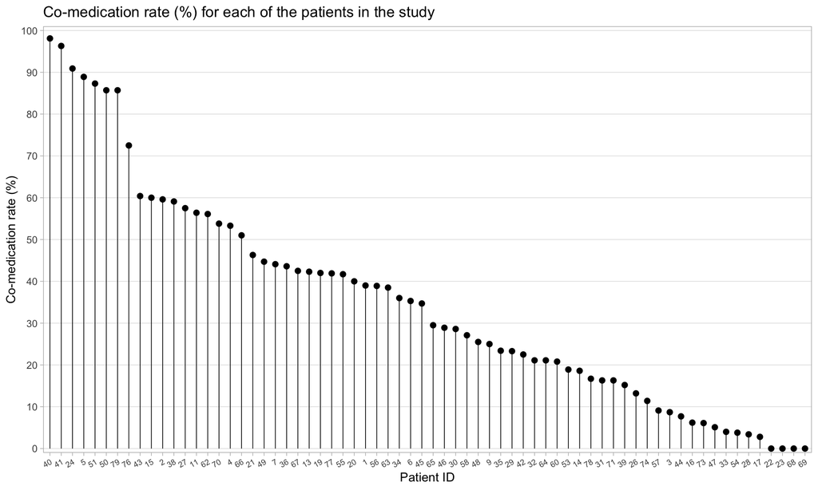

With the table and the plot above, we can have a quick glance on all the patient’s co-medication rate:

- There is a small group of patients that take both medications more than 70% of the time
- Most of the patients are below 60%, but they have been co-medicated at some point during their treatment
- 4 of the patients only use one of the medications during all their treatment (0% rate)

However, I think that we can have a nicer and more informative representation of the data set by plotting which medication each patient is taking (or whether they are being co-medicated) while also getting the co-medication rate:

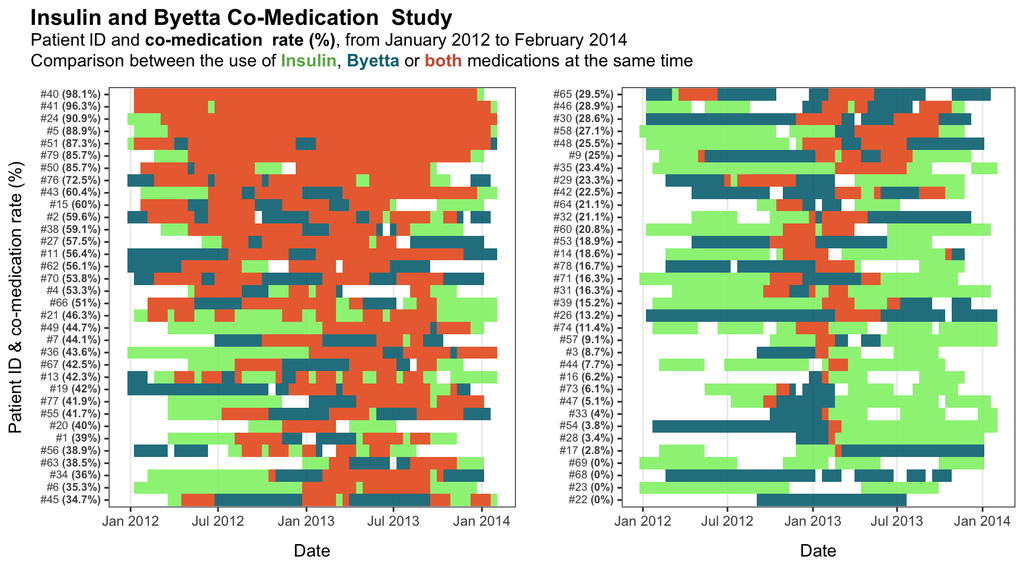

I believe this plot is a nice way to summarize the results we are interested in from the data set:

- We can identify when the patient is taking each drug on its own and when they are being co-medicated
- We can see how long each patient is under treatment, no matter what drug or drugs they are taking
- We can also identify any patterns on their behavior, such as switching from Insulin to Byetta or intermittent periods of co-medication
- Since they are still sorted by co-medication rate, we can easily find the most co-medicated patients and their co-medication rate in the y axis

## 3.- Improvements

**How can your algorithm or definition be improved?**

1. What real life patient behavior need to be catered for?
2. What are the potential issues from this data set?
3. If you could exclude certain records from your definition or algorithm, what kind of records would be excluded? Why?
4. Do you believe you are over-estimating or under-estimating co-medication rate? Why?

**a.**  
The most important real life patient behavior we have to consider is whether the patients are taking the medication after they buy it or not.

If the input data contained information about when each individual actually used the medications, the results would be much more reliable.

Furthermore, we can’t know about their adherence. If a medication that is supposed to last for a specific amount of time lasts much longer, that could suggest that the patients are not following the prescription correctly.

**b.**  
There are a few potential issues with this data set, besides what I mentioned above. For example:

- The period the data is divided into is 2 weeks, which is quite big to have a precise analysis in this scenario. If we could have more granularity, by asking the patients to specify each day they are taking each drug within a mobile app, for instance, that would improve our results.
- Another issue is related to missingness: Do the fortnights where we don’t have any information mean that the patients did not buy any of the drugs or that we don’t know? For this assessment, I assumed that the patients did not buy any drugs, but it could be that they did not report it or did not remember.

**c.**  
Some of the individuals buy new repeats of each medication much earlier (or later) than the theoretical lifespan.

- While higher delays could mean that they are just having a break in the treatment, smaller delays can be confusing. I can interpret it as batch buying to make it last longer, but it could also mean that the patients are using too much of the medication or that they simply lost it.

If I could exclude some patients from the analysis, I would remove the ones that are buying a medication much earlier than expected, such as some patients that are buying Insulin only 40 days after the previous purchase, instead of 90 days (plot not shown).

Nevertheless, checking this purchase delay would be useful in combination with usage information. If there were some inconsistencies, it could mean that the information about correct usage of the medication is not clear to some patients and could be improved.

**d.**  
My first answer would be that we are under-estimating the co-medication rate. Since we don’t have the dates where the patients took each medication, I assumed that they were taking them for as long as the medication is supposed to last. However, some patients buy the medication more often than required, but I only counted the lifespan after the *last* purchase.

On the other hand, we could also be over-estimating it. Since we are assuming that buying a drug means taking it, it could be possible that some patients stopped taking one of them after having side effects or any other reason.

In summary, to correctly calculate co-medication rate, we would need to have information about taking the medication, rather than buying it.

A work by [Dr. Sergio Ruiz Carmona](https://www.ruizsergio.com/)

*sruizcarmona@gmail.com*